# Basic homology based fitness

# Description

A first basic report exploring the effects of assigning fitness based on homology.

The ancestral sequence is specified as a sequence of only As.

A (very unrealistic) epitope is then specified as a sequence in which every 5th character is an A.

The fitness is based on the number of matches between the epitope and the sequence. A fitness of zero is assigned if the sequence perfectly matches the epitope and a fitness of one is assigned if there is no match at any point. For sequences that does neither perfectly match the epitope nor perfectly mismatch the epitope, fitness is assigned linearly beased on the number of matches.

Using this epitope, 10 pairs of datasets were generated.

First the entire quasispecies was simulated without taking fitness into account. Then, a copy is made of this genealogy and all individuals across all generations (excluding the first x generations) that has a fitness score lower than a cutoff were identified. These unfit individuals and ALL their decendents were then removed from the genealogy. The remaining individuals in the last generation of this dataset were then selected as a dataset.

To construct the partner of the dataset described above, a number of individuals are randomly selected from the last generation independent of any fitness considerations so that the same number of sequences are in each dataset.

**scribbles below this**

Start with an ancestor of only As and then run two comparisons:

basic_homolo_report

After the simulation is completed, two datasets are generated from each simulation: The first dataset is constructed by removing all the unfit individuals and all the individuals that have an unfit ancestor from the dataset. The remaining members of the last generation are then taken to be the dataset. A second dataset is made by sampling a random number of individuals from the last generation of the simulation irrespective of any fitness consideration. The number sampled is that same at the number of individuals in the first dataset.

This same process was repeated, but using an epitope in which each 5th letter is a C, thus the original ancestor does not match this epitope at all.

No difference was observed for the C-based epitopes. But this is a side effect of the way the fitness cutoffs were chosen.

The same pattern was observed for the deciles.

In the final table in the report you can see that no sequecnes were removed in any of the simulations for the c-based epitopes - so poor parameter choices on my part.

Here are many next steps to explore: 1) Run it for more generations 2) Run it with a larger R0 (more offspring per individual) 3) Tweak the fitness parameters / implement alternative fitness functions (maybe add a little mroe noise into the process?) 4) Pick more realisitc epitopes? But do we really care about this? We just want to see the effect of any immune pressure? 5) Play more with the templates used to generate the reports - I just picked the first one from a textbook and it defintely is not the optimal one 6) Carefully state the hypotheses we want to test (I think this should be the first next step) 7) Set up a readme file for the project that links to the report files (and store the primary results in the repo itself also) - just make the results more reachable.

# Simulation Results

The following graphs and tables present a summary of a set of simulations that can be divided into 4 groups.

Number of sequences used to compute distance matrices

| Sim. ID | Group Label | Number of sequences in simulated dataset | Number of sequences included in distance matrix |
| --- | --- | --- | --- |
| 1 | restricted_A | 3059 | 3059 |
| 2 | unrestricted_A | 3059 | 3059 |
| 3 | restricted_A | 17104 | 10000 |
| 4 | unrestricted_A | 17104 | 10000 |
| 5 | restricted_A | 5044 | 5044 |
| 6 | unrestricted_A | 5044 | 5044 |
| 7 | restricted_A | 3019 | 3019 |
| 8 | unrestricted_A | 3019 | 3019 |
| 9 | restricted_A | 14819 | 10000 |
| 10 | unrestricted_A | 14819 | 10000 |
| 11 | restricted_A | 5006 | 5006 |
| 12 | unrestricted_A | 5006 | 5006 |
| 13 | restricted_A | 17157 | 10000 |
| 14 | unrestricted_A | 17157 | 10000 |
| 15 | restricted_A | 16256 | 10000 |
| 16 | unrestricted_A | 16256 | 10000 |
| 17 | restricted_A | 27726 | 10000 |
| 18 | unrestricted_A | 27726 | 10000 |
| 19 | restricted_A | 12823 | 10000 |
| 20 | unrestricted_A | 12823 | 10000 |
| 21 | restricted_C | 262144 | 10000 |
| 22 | unrestricted_C | 262144 | 10000 |
| 23 | restricted_C | 262144 | 10000 |
| 24 | unrestricted_C | 262144 | 10000 |
| 25 | restricted_C | 262144 | 10000 |
| 26 | unrestricted_C | 262144 | 10000 |
| 27 | restricted_C | 262144 | 10000 |
| 28 | unrestricted_C | 262144 | 10000 |
| 29 | restricted_C | 262144 | 10000 |
| 30 | unrestricted_C | 262144 | 10000 |
| 31 | restricted_C | 262144 | 10000 |
| 32 | unrestricted_C | 262144 | 10000 |
| 33 | restricted_C | 262144 | 10000 |
| 34 | unrestricted_C | 262144 | 10000 |
| 35 | restricted_C | 262144 | 10000 |
| 36 | unrestricted_C | 262144 | 10000 |
| 37 | restricted_C | 262144 | 10000 |
| 38 | unrestricted_C | 262144 | 10000 |
| 39 | restricted_C | 262144 | 10000 |
| 40 | unrestricted_C | 262144 | 10000 |

The average pairwise HD in each group of simulations

| Group Label | Average Pairwise HD. | Normalized Average Pairwise HD. |
| --- | --- | --- |
| restricted_A | 60.93155 | 0.1218631 |
| unrestricted_A | 61.89973 | 0.1237995 |
| restricted_C | 62.37538 | 0.1247508 |
| unrestricted_C | 62.40293 | 0.1248059 |

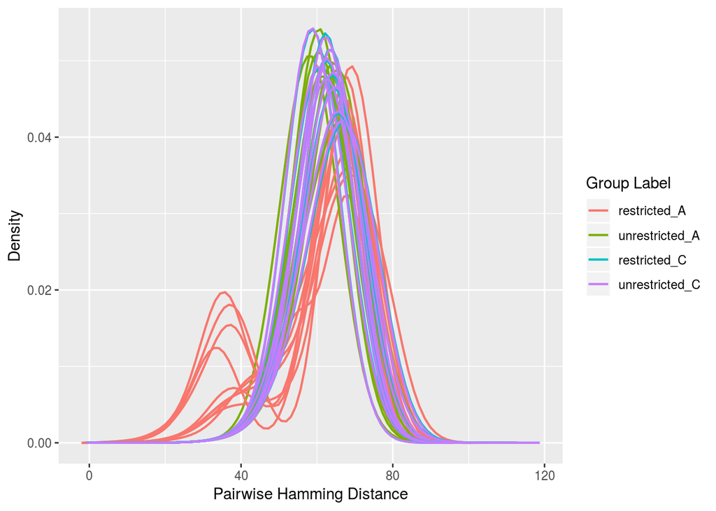

Density plot of the pariwise distances in the last generation

The deciles of the pairwise HDs

[output not shown]

Configuration with which sim_pop was called for the group for each group of simulations.

| Group Label | Argument | Value |
| --- | --- | --- |
| restricted_A | Number of Ancestors | 1 |
| restricted_A | Sequence Length | 500 |
| restricted_A | r0 | 2 |
| restricted_A | Number of Generations | 18 |
| restricted_A | Minimum Population Size | Inf |
| restricted_A | Mutator Function | mutator_uniform_fun |
| restricted_A | Mutator: mu | 0.004 |
| restricted_A | Fitness Evaluator | fitness_evaluator_homology_fun |
| restricted_A | Fitness Evaluator: comparators | XXXXAXXXXAXXXXAXXXXAXXXXAXXXXAXXXXAXXXXAXXXXAXXXXA… |
| restricted_A | Fitness Evaluator: h2fs | h2fs_univariate_linear_fun |
| unrestricted_A | Number of Ancestors | 1 |
| unrestricted_A | Sequence Length | 500 |
| unrestricted_A | r0 | 2 |
| unrestricted_A | Number of Generations | 18 |
| unrestricted_A | Minimum Population Size | Inf |
| unrestricted_A | Mutator Function | mutator_uniform_fun |
| unrestricted_A | Mutator: mu | 0.004 |
| unrestricted_A | Fitness Evaluator | fitness_evaluator_homology_fun |
| unrestricted_A | Fitness Evaluator: comparators | XXXXAXXXXAXXXXAXXXXAXXXXAXXXXAXXXXAXXXXAXXXXAXXXXA… |
| unrestricted_A | Fitness Evaluator: h2fs | h2fs_univariate_linear_fun |
| restricted_C | Number of Ancestors | 1 |
| restricted_C | Sequence Length | 500 |
| restricted_C | r0 | 2 |
| restricted_C | Number of Generations | 18 |
| restricted_C | Minimum Population Size | Inf |
| restricted_C | Mutator Function | mutator_uniform_fun |
| restricted_C | Mutator: mu | 0.004 |
| restricted_C | Fitness Evaluator | fitness_evaluator_homology_fun |
| restricted_C | Fitness Evaluator: comparators | XXXXCXXXXCXXXXCXXXXCXXXXCXXXXCXXXXCXXXXCXXXXCXXXXC… |
| restricted_C | Fitness Evaluator: h2fs | h2fs_univariate_linear_fun |
| unrestricted_C | Number of Ancestors | 1 |
| unrestricted_C | Sequence Length | 500 |
| unrestricted_C | r0 | 2 |
| unrestricted_C | Number of Generations | 18 |
| unrestricted_C | Minimum Population Size | Inf |
| unrestricted_C | Mutator Function | mutator_uniform_fun |
| unrestricted_C | Mutator: mu | 0.004 |
| unrestricted_C | Fitness Evaluator | fitness_evaluator_homology_fun |
| unrestricted_C | Fitness Evaluator: comparators | XXXXCXXXXCXXXXCXXXXCXXXXCXXXXCXXXXCXXXXCXXXXCXXXXC… |
| unrestricted_C | Fitness Evaluator: h2fs | h2fs_univariate_linear_fun |

Individuals per generation and the average distance to the original ancestor for the generation for all simulations grouped by simulation group.

| Group Label | Gen. Num. | n | Dist. to Ances. | Normalized Dist. | Fitness Score | Min. Fitness Score |
| --- | --- | --- | --- | --- | --- | --- |
| restricted_A | 0 | 10 | 0.000000 | 0.0000000 | 1.0000000 | 1.00 |
| restricted_A | 1 | 20 | 1.750000 | 0.0035000 | 1.0000000 | 1.00 |
| restricted_A | 2 | 40 | 3.625000 | 0.0072500 | 1.0000000 | 1.00 |
| restricted_A | 3 | 80 | 5.337500 | 0.0106750 | 1.0000000 | 1.00 |
| restricted_A | 4 | 160 | 7.356250 | 0.0147125 | 1.0000000 | 1.00 |
| restricted_A | 5 | 320 | 9.350000 | 0.0187000 | 1.0000000 | 1.00 |
| restricted_A | 6 | 640 | 11.340625 | 0.0226812 | 1.0000000 | 1.00 |
| restricted_A | 7 | 1280 | 13.376563 | 0.0267531 | 1.0000000 | 1.00 |
| restricted_A | 8 | 122 | 20.032787 | 0.0400656 | 0.0304098 | 0.03 |
| restricted_A | 9 | 244 | 21.971311 | 0.0439426 | 0.0310246 | 0.03 |
| restricted_A | 10 | 485 | 23.865979 | 0.0477320 | 0.0314021 | 0.03 |
| restricted_A | 11 | 965 | 25.699482 | 0.0513990 | 0.0318446 | 0.03 |
| restricted_A | 12 | 1924 | 27.555094 | 0.0551102 | 0.0324324 | 0.03 |
| restricted_A | 13 | 3837 | 29.422466 | 0.0588449 | 0.0330884 | 0.03 |
| restricted_A | 14 | 7656 | 31.277691 | 0.0625554 | 0.0339107 | 0.03 |
| restricted_A | 15 | 15290 | 33.102027 | 0.0662041 | 0.0346965 | 0.03 |
| restricted_A | 16 | 30548 | 34.940520 | 0.0698810 | 0.0355984 | 0.03 |
| restricted_A | 17 | 61046 | 36.760902 | 0.0735218 | 0.0365578 | 0.03 |
| restricted_A | 18 | 122013 | 38.567587 | 0.0771352 | 0.0375505 | 0.03 |
| unrestricted_A | 0 | 10 | 0.000000 | 0.0000000 | 1.0000000 | 1.00 |
| unrestricted_A | 1 | 20 | 1.750000 | 0.0035000 | 1.0000000 | 1.00 |
| unrestricted_A | 2 | 40 | 3.625000 | 0.0072500 | 1.0000000 | 1.00 |
| unrestricted_A | 3 | 80 | 5.337500 | 0.0106750 | 1.0000000 | 1.00 |
| unrestricted_A | 4 | 160 | 7.356250 | 0.0147125 | 1.0000000 | 1.00 |
| unrestricted_A | 5 | 320 | 9.350000 | 0.0187000 | 1.0000000 | 1.00 |
| unrestricted_A | 6 | 640 | 11.340625 | 0.0226812 | 1.0000000 | 1.00 |
| unrestricted_A | 7 | 1280 | 13.376563 | 0.0267531 | 1.0000000 | 1.00 |
| unrestricted_A | 8 | 2560 | 15.322656 | 0.0306453 | 0.0149648 | 0.00 |
| unrestricted_A | 9 | 5120 | 17.251562 | 0.0345031 | 0.0164531 | 0.00 |
| unrestricted_A | 10 | 10240 | 19.152344 | 0.0383047 | 0.0178711 | 0.00 |
| unrestricted_A | 11 | 20480 | 21.042090 | 0.0420842 | 0.0192500 | 0.00 |
| unrestricted_A | 12 | 40960 | 22.931519 | 0.0458630 | 0.0206255 | 0.00 |
| unrestricted_A | 13 | 81920 | 24.803613 | 0.0496072 | 0.0219762 | 0.00 |
| unrestricted_A | 14 | 163840 | 26.672583 | 0.0533452 | 0.0233286 | 0.00 |
| unrestricted_A | 15 | 327680 | 28.528641 | 0.0570573 | 0.0246708 | 0.00 |
| unrestricted_A | 16 | 655360 | 30.377931 | 0.0607559 | 0.0260033 | 0.00 |
| unrestricted_A | 17 | 1310720 | 32.217689 | 0.0644354 | 0.0273315 | 0.00 |
| unrestricted_A | 18 | 122013 | 34.846033 | 0.0696921 | 0.0294570 | 0.00 |
| restricted_C | 0 | 10 | 0.000000 | 0.0000000 | 1.0000000 | 1.00 |
| restricted_C | 1 | 20 | 2.000000 | 0.0040000 | 1.0000000 | 1.00 |
| restricted_C | 2 | 40 | 3.875000 | 0.0077500 | 1.0000000 | 1.00 |
| restricted_C | 3 | 80 | 5.987500 | 0.0119750 | 1.0000000 | 1.00 |
| restricted_C | 4 | 160 | 7.887500 | 0.0157750 | 1.0000000 | 1.00 |
| restricted_C | 5 | 320 | 9.878125 | 0.0197563 | 1.0000000 | 1.00 |
| restricted_C | 6 | 640 | 11.814063 | 0.0236281 | 1.0000000 | 1.00 |
| restricted_C | 7 | 1280 | 13.724219 | 0.0274484 | 1.0000000 | 1.00 |
| restricted_C | 8 | 2560 | 15.655469 | 0.0313109 | 0.9813906 | 0.90 |
| restricted_C | 9 | 5120 | 17.605664 | 0.0352113 | 0.9783691 | 0.89 |
| restricted_C | 10 | 10240 | 19.502246 | 0.0390045 | 0.9754580 | 0.89 |
| restricted_C | 11 | 20480 | 21.413281 | 0.0428266 | 0.9725103 | 0.88 |
| restricted_C | 12 | 40960 | 23.304565 | 0.0466091 | 0.9696619 | 0.87 |
| restricted_C | 13 | 81920 | 25.180273 | 0.0503605 | 0.9667928 | 0.86 |
| restricted_C | 14 | 163840 | 27.049396 | 0.0540988 | 0.9639476 | 0.86 |
| restricted_C | 15 | 327680 | 28.904489 | 0.0578090 | 0.9611136 | 0.85 |
| restricted_C | 16 | 655360 | 30.751881 | 0.0615038 | 0.9583008 | 0.84 |
| restricted_C | 17 | 1310720 | 32.586772 | 0.0651735 | 0.9555102 | 0.83 |
| restricted_C | 18 | 2621440 | 34.413648 | 0.0688273 | 0.9527276 | 0.83 |
| unrestricted_C | 0 | 10 | 0.000000 | 0.0000000 | 1.0000000 | 1.00 |
| unrestricted_C | 1 | 20 | 2.000000 | 0.0040000 | 1.0000000 | 1.00 |
| unrestricted_C | 2 | 40 | 3.875000 | 0.0077500 | 1.0000000 | 1.00 |
| unrestricted_C | 3 | 80 | 5.987500 | 0.0119750 | 1.0000000 | 1.00 |
| unrestricted_C | 4 | 160 | 7.887500 | 0.0157750 | 1.0000000 | 1.00 |
| unrestricted_C | 5 | 320 | 9.878125 | 0.0197563 | 1.0000000 | 1.00 |
| unrestricted_C | 6 | 640 | 11.814063 | 0.0236281 | 1.0000000 | 1.00 |
| unrestricted_C | 7 | 1280 | 13.724219 | 0.0274484 | 1.0000000 | 1.00 |
| unrestricted_C | 8 | 2560 | 15.655469 | 0.0313109 | 0.9813906 | 0.90 |
| unrestricted_C | 9 | 5120 | 17.605664 | 0.0352113 | 0.9783691 | 0.89 |
| unrestricted_C | 10 | 10240 | 19.502246 | 0.0390045 | 0.9754580 | 0.89 |
| unrestricted_C | 11 | 20480 | 21.413281 | 0.0428266 | 0.9725103 | 0.88 |
| unrestricted_C | 12 | 40960 | 23.304565 | 0.0466091 | 0.9696619 | 0.87 |
| unrestricted_C | 13 | 81920 | 25.180273 | 0.0503605 | 0.9667928 | 0.86 |
| unrestricted_C | 14 | 163840 | 27.049396 | 0.0540988 | 0.9639476 | 0.86 |
| unrestricted_C | 15 | 327680 | 28.904489 | 0.0578090 | 0.9611136 | 0.85 |
| unrestricted_C | 16 | 655360 | 30.751881 | 0.0615038 | 0.9583008 | 0.84 |
| unrestricted_C | 17 | 1310720 | 32.586772 | 0.0651735 | 0.9555102 | 0.83 |
| unrestricted_C | 18 | 2621440 | 34.413648 | 0.0688273 | 0.9527276 | 0.83 |

# Total Running Time

```
##      user    system   elapsed
## 243313.26   1673.28 178461.11
```